# Exploring the Visual Nature of London Urban Development with Convolutional Neural Networks

# 7 - Final Data Model

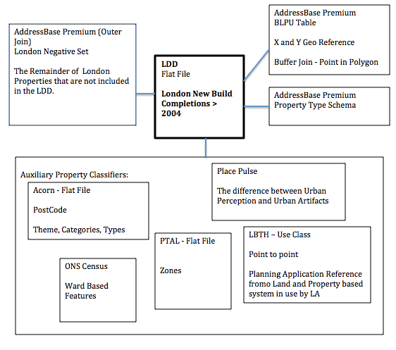

# Summary

- Fuzzy Set Limitations.
- Patchy Set Data Limitations.
- Completion Date Filter + Dataset of n = 66000
- Visual Perceptual Typological Features

# Appendix - Further Model Exploration

# 1 -Pyviz Datashader Render of n = 100K London Negative Set and AB Combined

- Use Holoviews Virtual Env
- Datashader is a graphics pipeline system for creating meaningful representations of large datasets: https://datashader.org/index.html
- Aim: Visualize Density of New vs Old London(LDD vs Non-LDD Addressbase Data)
- In Progress...

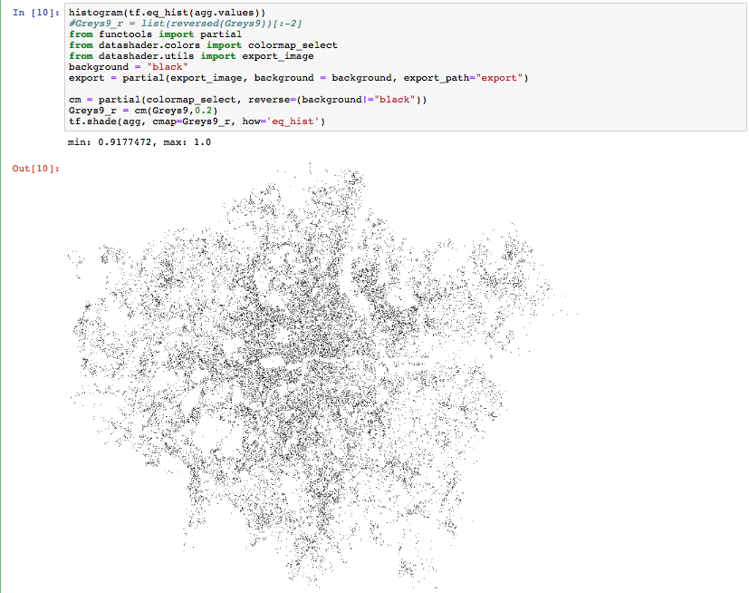

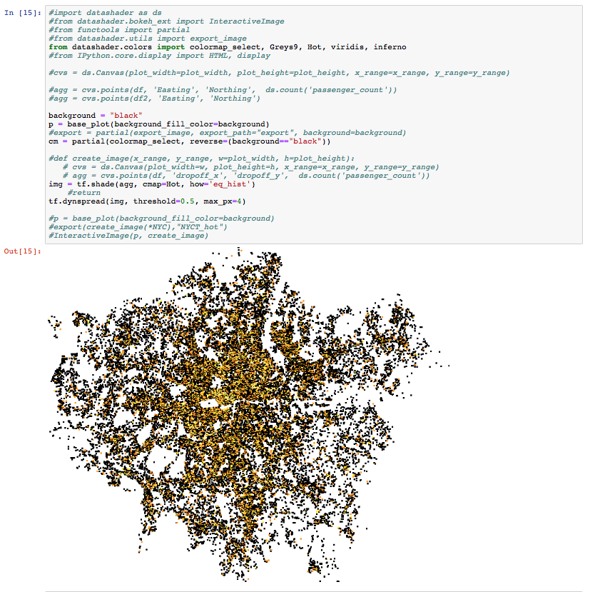

# 2 - Processing 3 Time Lapse LDD Animation

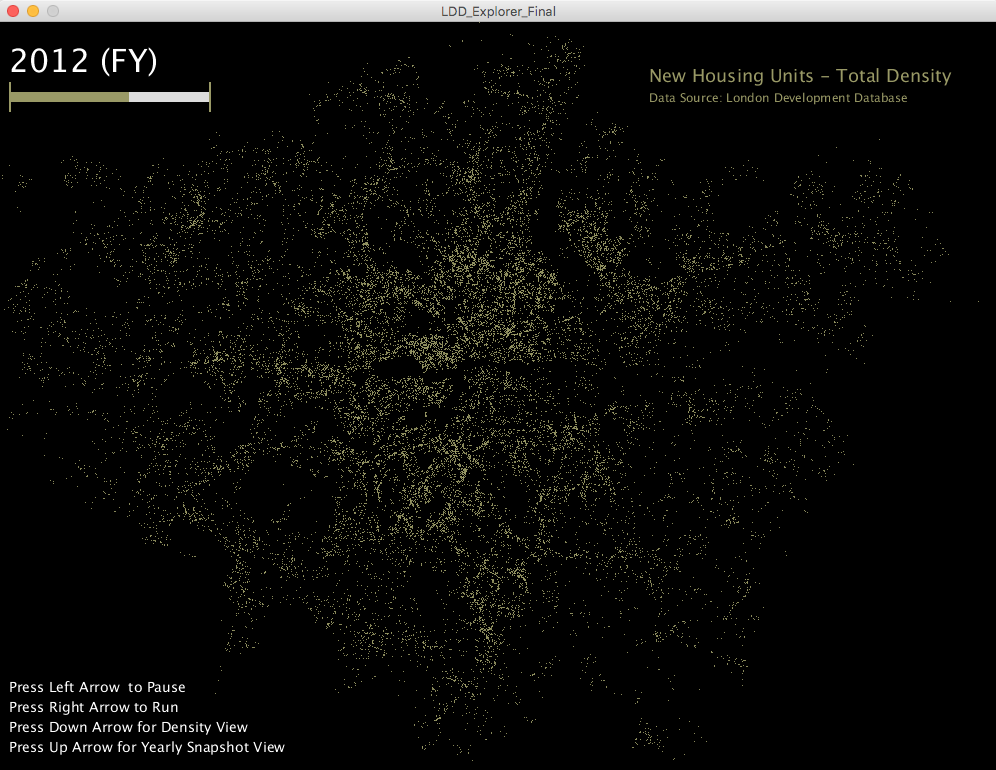

[figure not shown]